# SDG Data Analysis Tutorial

## 3. Visualizing and Analyzing SDG Data

To begin, it may be helpful to investigate the data for a single indicator. Let’s check out which ones made it into our selection

```r
table(ind.sum.cont.5$Indicator)
```

```
##
##   1.1.1   1.2.1   1.3.1   1.4.1   1.5.1   1.5.2   1.5.3   1.5.4   1.a.2  10.1.1
##       0       0       0       0       0       0       0       0       0       0
##  10.4.1  10.5.1  10.6.1  10.7.2  10.a.1  10.b.1  10.c.1  11.1.1  11.5.1  11.5.2
##       1       0       0       0       0       1       0       0       0       0
##  11.6.1  11.6.2  11.b.1  11.b.2  12.1.1  12.2.2  12.4.1  12.4.2  12.b.1  12.c.1
##       0       0       0       0       0       0       0       0       0       0
##  13.1.1  13.1.2  13.1.3  14.6.1  14.b.1  15.1.1  15.1.2  15.2.1  15.3.1  15.4.1
##       0       0       0       0       0       0       0       0       0       1
##  15.4.2  15.5.1  15.6.1  15.8.1  15.a.1  15.b.1  16.1.1  16.1.3  16.1.4 16.10.2
##       0       1       0       0       1       1       0       0       0       0
##  16.2.1  16.2.2  16.2.3  16.3.2  16.5.1  16.5.2  16.6.1  16.8.1  16.9.1  16.a.1
##       0       0       0       0       0       0       0       0       0       0
##  17.1.1  17.1.2 17.10.1 17.12.1 17.15.1 17.16.1 17.18.2 17.18.3 17.19.1 17.19.2
##       0       1       0       0       0       0       0       0       0       0
##  17.3.2  17.4.1  17.6.1  17.8.1  17.9.1   2.1.1   2.1.2   2.2.1   2.2.2   2.3.1
##       1       1       0       1       1       0       0       0       0       0
##   2.3.2   2.5.1   2.5.2   2.a.1   2.a.2   2.c.1   3.1.1   3.1.2   3.2.1   3.2.2
##       0       0       0       0       1       0       1       0       0       0
##   3.3.1   3.3.2   3.3.3   3.3.4   3.3.5   3.4.1   3.4.2   3.5.2   3.6.1   3.7.1
##       0       1       0       0       1       0       0       0       0       0
##   3.7.2   3.8.1   3.8.2   3.9.1   3.9.2   3.9.3   3.a.1   3.b.1   3.b.2   3.c.1
##       0       0       0       0       0       0       0       0       0       0
##   3.d.1   4.1.1   4.2.1   4.2.2   4.5.1   4.a.1   4.b.1   4.c.1   5.1.1   5.2.1
##       0       0       0       0       0       0       0       0       0       0
##   5.3.1   5.3.2   5.5.1   5.5.2   5.6.1   5.a.1   5.c.1   6.1.1   6.2.1   6.3.1
##       0       0       1       0       0       0       0       0       0       0
##   6.3.2   6.4.1   6.4.2   6.5.1   6.5.2   6.6.1   6.a.1   6.b.1   7.1.1   7.1.2
##       0       0       0       0       0       0       1       1       0       0
##   7.2.1   7.3.1   7.a.1   8.1.1  8.10.1  8.10.2   8.2.1   8.3.1   8.4.2   8.5.2
##       1       1       1       1       0       0       1       0       0       0
##   8.6.1   8.7.1   8.8.2   8.a.1   9.1.2   9.2.1   9.2.2   9.3.2   9.5.1   9.5.2
##       0       0       0       0       0       0       0       0       0       0
##   9.a.1   9.b.1   9.c.1
##       1       1       0
```

For this example, we will use Indicator 3.1.1 Maternal mortality ratio. First we subset the data and select the columns with relevant information

```r
test<- subset(sdg.data2, Indicator=="3.1.1")   #the indicator number is in quotation marks, because the values are stored as factors, not numbers

test <- test[,c("Goal", "Target", "Indicator", "SeriesDescription", "GeoAreaName", "TimePeriod", "Value", "Units", "Source")]

print(test)
```

```
##     Goal Target Indicator        SeriesDescription GeoAreaName TimePeriod Value
## 691    3    3.1     3.1.1 Maternal mortality ratio      Uganda       2000   578
## 692    3    3.1     3.1.1 Maternal mortality ratio      Uganda       2001   550
## 693    3    3.1     3.1.1 Maternal mortality ratio      Uganda       2002   537
## 694    3    3.1     3.1.1 Maternal mortality ratio      Uganda       2003   520
## 695    3    3.1     3.1.1 Maternal mortality ratio      Uganda       2004   512
## 696    3    3.1     3.1.1 Maternal mortality ratio      Uganda       2005   491
## 697    3    3.1     3.1.1 Maternal mortality ratio      Uganda       2006   473
## 698    3    3.1     3.1.1 Maternal mortality ratio      Uganda       2007   465
## 699    3    3.1     3.1.1 Maternal mortality ratio      Uganda       2008   455
## 700    3    3.1     3.1.1 Maternal mortality ratio      Uganda       2009   442
## 701    3    3.1     3.1.1 Maternal mortality ratio      Uganda       2010   430
## 702    3    3.1     3.1.1 Maternal mortality ratio      Uganda       2011   419
## 703    3    3.1     3.1.1 Maternal mortality ratio      Uganda       2012   412
## 704    3    3.1     3.1.1 Maternal mortality ratio      Uganda       2013   401
```

[output cut: 42 more lines]

A quick plot will show us how the value has changed over time. Great to see that maternal mortality has declined! (Note: Whenever data looks this smooth, it is usually estimated. A quick look at the raw data shows that these are estimated by WHO, not reported data!)

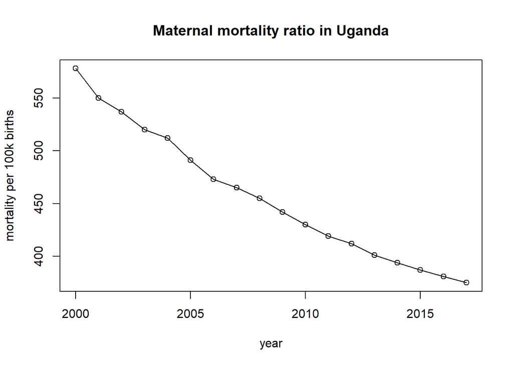

```r
plot(test$TimePeriod, test$Value, ylab="mortality per 100k births", xlab="year", main="Maternal mortality ratio in Uganda")
lines(test$TimePeriod, test$Value)
```

### Investigating Trade-offs and Synergies Between SDG Indicators

Now that we have gained a handle on the data, it is time to pursue the actual goal; looking for relationships among different time series of SDG indicators.

[**Note:** Time series are a special type of data. For starters, the data points over time are not statistically independent, making direct comparisons a little tricky. On the flipside, there are some great benefits to this type of data. We can observe change over time, investigate how the previous value affects the next one (a phenomenon termed *temporal autocorrelation*), and much more. This type of analysis is commonly used in pattern analysis and forecasting, e.g. for stock markets, climatology, or ecology. You can make a living analyzing time series!! While this goes beyond the scope of this tutorial and course, I highly recommend learning more about time series analysys, for example here: (https://nwfsc-timeseries.github.io/atsa-labs/)]

Before we are ready to pursue this goal, we need to **standardize the data**, because a direct comparison of indicator values is often not that meaningful. Standardizing the data means centering and scaling the data so that the mean value becomes zero and the distribution of the data falls within two standard deviations (SD). This allows us to make the comparison “A change in 1 SD parameter X was matched by a change in 0.5 SD in parameter Y”.

Let’s start by comparing two of our “clean” indicators:

```r
test2<- subset(sdg.data2, Indicator=="5.5.1")   #the indicator number is in quotation marks, because the values are stored as factors, not numbers

test2 <- test2[,c("Goal", "Target", "Indicator", "SeriesDescription", "GeoAreaName", "TimePeriod", "Value", "Units", "Source")]

print(test2)
```

```
##      Goal Target Indicator                                SeriesDescription
## 1734    5    5.5     5.5.1 Number of seats in national parliaments (number)
## 1735    5    5.5     5.5.1 Number of seats in national parliaments (number)
## 1736    5    5.5     5.5.1 Number of seats in national parliaments (number)
## 1737    5    5.5     5.5.1 Number of seats in national parliaments (number)
## 1738    5    5.5     5.5.1 Number of seats in national parliaments (number)
## 1739    5    5.5     5.5.1 Number of seats in national parliaments (number)
## 1740    5    5.5     5.5.1 Number of seats in national parliaments (number)
## 1741    5    5.5     5.5.1 Number of seats in national parliaments (number)
## 1742    5    5.5     5.5.1 Number of seats in national parliaments (number)
## 1743    5    5.5     5.5.1 Number of seats in national parliaments (number)
## 1744    5    5.5     5.5.1 Number of seats in national parliaments (number)
## 1745    5    5.5     5.5.1 Number of seats in national parliaments (number)
## 1746    5    5.5     5.5.1 Number of seats in national parliaments (number)
## 1747    5    5.5     5.5.1 Number of seats in national parliaments (number)
```

[output cut: 51 more lines]

Let’s make a plot:

[figure not shown]

```r
plot(test2$TimePeriod, test2$Value, ylab="number of women in parliament", xlab="year", main="Female members of parliament in Uganda")
lines(test2$TimePeriod, test2$Value)
```

To compare the two indicators, we first use centering and scaling to standardize the data. Then we merge the two data frames. First for the first parameter… [Note: here we have a case of a declining number that is getting closer to the desired outcome. Therefore, we invert the data values after standardizing!]

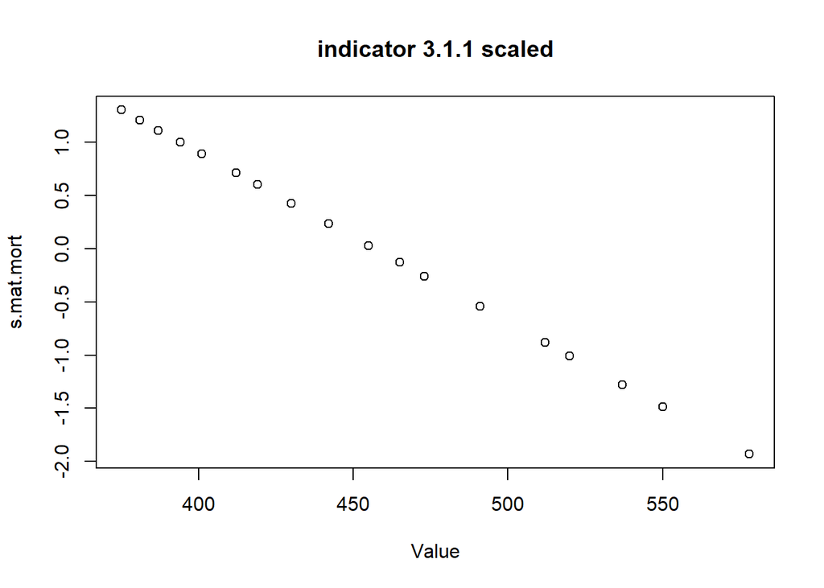

```r
test<-test[,c("Value", "TimePeriod")]
test$s.mat.mort <- scale (test$Value, center=T) #this standardizes the data by centering it on zero and dividing it by 2 standard deviations
test$s.mat.mort <- test$s.mat.mort * -1  #this inverts the standardized data
plot(s.mat.mort~Value, test, main="indicator 3.1.1 scaled")
```

Now for the second one:

```r
test2<-test2[,c("Value", "TimePeriod")]
test2$s.women.parl <- scale (test2$Value, center=T)
```

Time to merge the data frames and plot their relationship

[figure not shown]

```r
test.comp<-merge(test, test2, by="TimePeriod") #this combines the two data frames by matching years


plot(s.mat.mort~s.women.parl, test.comp, xlab="maternal mortality", ylab="women in parliament", main="SDG 5.5.1 vs SDG 3.1.1")
abline(lm(s.mat.mort~s.women.parl, test.comp))
```

This looks promising! Let’s use a Pearson correlation test to determine whether the two indicators are significantly correlated.

```r
cor.test(test.comp$s.mat.mort, test.comp$s.women.parl, method="pearson")
```

```
##
##  Pearson's product-moment correlation
##
## data:  test.comp$s.mat.mort and test.comp$s.women.parl
## t = 7.6312, df = 16, p-value = 1.017e-06
## alternative hypothesis: true correlation is not equal to 0
## 95 percent confidence interval:
##  0.7141322 0.9568908
## sample estimates:
##       cor
## 0.8857028
```

While it would be interesting to investigate each pairing to this detail, we now need to find a way to compare a large number of indicators simultaneously.

### Scaling up to the Comparison of Multiple Indicators

A number of R packages are useful when analyzing multiple time series. Here, we use elements of the package “ncf”, a package designed to analyze spatial covariance functions (https://cran.r-project.org/web/packages/ncf/ncf.pdf). While we are not doing spatial analyses for this course, the package contains the useful command `cor2()` which creates a cross-correlation matrix for a set of time series, which is exactly what we need!

[Note: Remember the workshop analogy? Here, we are using a tool from one tool kit to achieve another goal.]

To download and install the “ncf” package, use the command `install.package(ncf)`.

First, load the package using `library()`

```r
library(ncf)
```

By looking at the help file, we can see what is required to run `cor2()`

```r
?cor2()
```

Looks like we need a matrix, consisting of our time series data, one Indicator per row (aka in the wide format)

[Wait, what’s the difference between a matrix and a data frame? Let’s ask R using `?matrix` and `?data.frame`]

**First**, let’s standardize the data for the “clean” indicators we found earlier.

Let’s use the data frame we extracted. We called it “sdg.data2”. A quick look with `str()` to remind us what is there.

```r
str(sdg.data2)
```

```
## 'data.frame':    440 obs. of  46 variables:
##  $ Goal                                : int  2 2 2 2 2 2 2 2 2 2 ...
##  $ Target                              : Factor w/ 117 levels "1.1","1.2","1.3",..: 61 61 61 61 61 61 61 61 61 61 ...
##  $ Indicator                           : Factor w/ 163 levels "1.1.1","1.2.1",..: 85 85 85 85 85 85 85 85 85 85 ...
##  $ SeriesCode                          : Factor w/ 300 levels "AG_FPA_CFPI",..: 22 22 22 22 22 22 22 22 22 22 ...
##  $ SeriesDescription                   : Factor w/ 300 levels "[ILO] Proportion of employed population covered in the event of work injury, by sex (%)",..: 280 280 280 280 280 280 280 280 280 280 ...
##  $ GeoAreaCode                         : int  800 800 800 800 800 800 800 800 800 800 ...
##  $ GeoAreaName                         : Factor w/ 1 level "Uganda": 1 1 1 1 1 1 1 1 1 1 ...
##  $ TimePeriod                          : int  2000 2001 2002 2003 2004 2005 2006 2007 2008 2009 ...
##  $ Value                               : num  126.9 113.6 37.2 52 89.3 ...
##  $ Time_Detail                         : Factor w/ 92 levels "","1998-2002",..: 5 12 15 18 21 24 28 33 36 39 ...
##  $ UpperBound                          : num  NA NA NA NA NA NA NA NA NA NA ...
##  $ LowerBound                          : num  NA NA NA NA NA NA NA NA NA NA ...
##  $ BasePeriod                          : int  NA NA NA NA NA NA NA NA NA NA ...
##  $ Source                              : Factor w/ 221 levels "2018 Partner Report on Support to Statistics (PRESS), the Partnership in Statistics for Development in the 21st"| __truncated__,..: 131 131 131 131 131 131 131 131 131 131 ...
```

[output cut: 32 more lines]

```r
sdg.data2$Indicator<-as.character(sdg.data2$Indicator) #we are converting the factor to character strings
sdg.data2$Indicator<-factor(sdg.data2$Indicator) #and back
table(sdg.data2$Indicator)
```

```
##
## 10.4.1 10.b.1 15.4.1 15.5.1 15.a.1 15.b.1 17.1.2 17.3.2 17.4.1 17.8.1 17.9.1
##     14     18     20     21     16     16     19     19     19     18     18
##  2.a.2  3.1.1  3.3.2  3.3.5  5.5.1  6.a.1  6.b.1  7.2.1  7.3.1  7.a.1  8.1.1
##     18     18     19      9     21     18     10     18     18     18     19
##  8.2.1  9.a.1  9.b.1
##     20     18     18
```

Let’s see which years are covered by which data, for each indicator

```r
table(sdg.data2$Indicator, sdg.data2$TimePeriod)
```

```
##
##          2000 2001 2002 2003 2004 2005 2006 2007 2008 2009 2010 2011 2012 2013
##   10.4.1    0    0    0    0    1    1    1    1    1    1    1    1    1    1
##   10.b.1    1    1    1    1    1    1    1    1    1    1    1    1    1    1
##   15.4.1    1    1    1    1    1    1    1    1    1    1    1    1    1    1
##   15.5.1    1    1    1    1    1    1    1    1    1    1    1    1    1    1
##   15.a.1    0    0    1    1    1    1    1    1    1    1    1    1    1    1
##   15.b.1    0    0    1    1    1    1    1    1    1    1    1    1    1    1
##   17.1.2    1    1    1    1    1    1    1    1    1    1    1    1    1    1
##   17.3.2    1    1    1    1    1    1    1    1    1    1    1    1    1    1
##   17.4.1    1    1    1    1    1    1    1    1    1    1    1    1    1    1
##   17.8.1    1    1    1    1    1    1    1    1    1    1    1    1    1    1
##   17.9.1    1    1    1    1    1    1    1    1    1    1    1    1    1    1
##   2.a.2     1    1    1    1    1    1    1    1    1    1    1    1    1    1
##   3.1.1     1    1    1    1    1    1    1    1    1    1    1    1    1    1
##   3.3.2     1    1    1    1    1    1    1    1    1    1    1    1    1    1
##   3.3.5     0    0    0    0    0    0    0    0    0    0    1    1    1    1
##   5.5.1     1    1    1    1    1    1    1    1    1    1    1    1    1    1
##   6.a.1     1    1    1    1    1    1    1    1    1    1    1    1    1    1
##   6.b.1     0    0    0    0    0    0    0    0    0    0    2    0    2    0
##   7.2.1     1    1    1    1    1    1    1    1    1    1    1    1    1    1
##   7.3.1     1    1    1    1    1    1    1    1    1    1    1    1    1    1
##   7.a.1     1    1    1    1    1    1    1    1    1    1    1    1    1    1
##   8.1.1     1    1    1    1    1    1    1    1    1    1    1    1    1    1
##   8.2.1     1    1    1    1    1    1    1    1    1    1    1    1    1    1
##   9.a.1     1    1    1    1    1    1    1    1    1    1    1    1    1    1
##   9.b.1     1    1    1    1    1    1    1    1    1    1    1    1    1    1
##
##          2014 2015 2016 2017 2018 2019 2020
##   10.4.1    1    1    1    1    0    0    0
##   10.b.1    1    1    1    1    0    0    0
##   15.4.1    1    1    1    1    1    1    0
##   15.5.1    1    1    1    1    1    1    1
##   15.a.1    1    1    1    1    0    0    0
##   15.b.1    1    1    1    1    0    0    0
##   17.1.2    1    1    1    1    1    0    0
##   17.3.2    1    1    1    1    1    0    0
##   17.4.1    1    1    1    1    1    0    0
##   17.8.1    1    1    1    1    0    0    0
##   17.9.1    1    1    1    1    0    0    0
##   2.a.2     1    1    1    1    0    0    0
##   3.1.1     1    1    1    1    0    0    0
##   3.3.2     1    1    1    1    1    0    0
##   3.3.5     1    1    1    1    1    0    0
##   5.5.1     1    1    1    1    1    1    1
##   6.a.1     1    1    1    1    0    0    0
##   6.b.1     2    0    0    0    0    4    0
##   7.2.1     1    1    1    1    0    0    0
##   7.3.1     1    1    1    1    0    0    0
##   7.a.1     1    1    1    1    0    0    0
##   8.1.1     1    1    1    1    1    0    0
##   8.2.1     1    1    1    1    1    1    0
##   9.a.1     1    1    1    1    0    0    0
##   9.b.1     1    1    1    1    0    0    0
```

Great! With the exception of indicator “6.b.1”, we have only one value per year. Let’s exclude the culprit (for now).